# Effects of Soil Warming Plus Nitrogen Addition on Plant Richness and Diversity at Harvard Forest

Roy Moger-Reischer and Katie Beidler, Quantitative Biodiversity, Indiana University

09 March, 2017

## ABSTRACT

[output not shown]

## 1) INTRODUCTION

[output not shown]

**Research Question**: What are the short-term effects of soil warming plus N additions on plant richness and diversity at Harvard Forest?

> *Hypothesis 1*: Richness and diversity will decrease over time in warming and N treatments.

> *Hypothesis 2*: Soil repsiration will be higher in warmed plots, lower in N-amended plots.

## 2) SETUP

### Retrieve and Set Working Directory

## 3) DESCRIPTION OF DATA

The overall objective of this project is to investigate whether soil warming and N fertilization alter plant biodiversity through time (2006-2009). In 2006 a group at the Harvard Forest LTER led by Serita Frey, initiated an experiment to assess the interactive effects of these two environmental changes on plant, arthropod, and soil microbe community composition, and soil respiration (Frey 2009). Six replicate plots for each of four treatments (Control; N deposition; heated; N & heated interaction) were established. N deposition plots received 50 kg N/ha/yr. Heated plots were warmed to 5 degrees C above ambient temperature. The data for this project came from the Harvard Forest LTER site. [link](https://portal.lternet.edu/nis/metadataviewer?packageid=knb-lter-hfr.45.24)

### B.Install Packages

This analysis will require several packages. The require() function in R returns TRUE if the package was successfully loaded or FALSE if the package failed to load. This for loop loads each package and installs the package when require() returns FALSE.

```r
package.list = c('vegan', 'tidyr', 'dplyr', 'codyn', 'ggplot2','betapart','splitstackshape','cowplot', 'MullerPlot','scales','grid','RColorBrewer','lubridate', 'reshape2', 'lubridate','multcomp','TTR', 'xtable', 'pander', 'png', 'grid', 'tseries', 'nlme', 'forecast', 'lsmeans', 'devtools', 'lme4')

for (package in package.list) {
if (!require(package, character.only = TRUE, quietly = TRUE)) {
install.packages(package, repos='http://cran.us.r-project.org')
library(package, character.only = TRUE) }
}
```

## 4) LOADING DATA

### A. Description of Data Set

1. ‘plant’: This datasheet is the plot by species abundance (Number of stems) matrix grouped by treatment and year.
2. ‘resp’:This datasheet includes field season measurements of soil respiration (CO2 flux (mg C m-2 h-1)))

```r
#plant = read.csv("./HF_plants_treat.csv")
#resp = read.csv("./HF_soilresp.csv", stringsAsFactors = FALSE)

plant=read.csv("C:\\Users\\rmoge\\GitHub\\QB2017_DivPro\\Data\\HF_plants_treat.csv")
resp<-read.csv("C:\\Users\\rmoge\\GitHub\\QB2017_DivPro\\Data\\HF_soilresp.csv")
```

### B. Data Wrangling

Subsetting the data by year and producing site by species matrices.

```r
# Making the Site by Species Matrix for the plant data set
plant_sbys = plant[ ,6:43]

# Subsetting the data into the different years
plant_06 = (filter(plant, year == 2006))
plant_07 = (filter(plant, year == 2007))
plant_08 = (filter(plant, year == 2008))
plant_09 = (filter(plant, year == 2009))

# Separating out the treatments from the site by species matrices
plant_06_sbys = plant_06[ ,6:43]
plant_07_sbys = plant_07[ ,6:43]
plant_08_sbys = plant_08[ ,6:43]
plant_09_sbys = plant_09[ ,6:43]
```

## 5) ANALYSIS: FIGURES AND STATISTICS

```r
# Visualizing the Plant data set
str(plant, max.level = 1)
```

```
## 'data.frame':    96 obs. of  45 variables:
##  $ year      : int  2006 2006 2006 2006 2006 2006 2007 2007 2007 2007 ...
##  $ plot      : int  1 12 14 19 20 24 1 12 14 19 ...
##  $ treatment : int  1 1 1 1 1 1 1 1 1 1 ...
##  $ N_treat   : Factor w/ 2 levels "control","N fertilized": 1 1 1 1 1 1 1 1 1 1 ...
##  $ heat_treat: Factor w/ 2 levels "control","heated": 1 1 1 1 1 1 1 1 1 1 ...
##  $ acersp    : int  0 1 0 0 0 0 0 0 0 0 ...
##  $ acepen    : int  2 4 13 17 8 18 3 5 13 12 ...
##  $ acerub    : int  3 2 6 0 1 1 5 5 7 2 ...
##  $ aranud    : int  14 0 16 19 9 7 11 0 15 28 ...
##  $ aritri    : int  0 0 0 0 0 0 0 0 0 0 ...
##  $ betale    : int  0 0 1 0 0 0 1 0 2 0 ...
##  $ betlen    : int  1 0 0 0 0 0 0 0 0 0 ...
##  $ betspp    : int  0 0 0 0 0 0 1 0 0 0 ...
##  $ carpen    : int  2 0 2 139 1 0 32 0 1 65 ...
```

[output cut: 31 more lines]

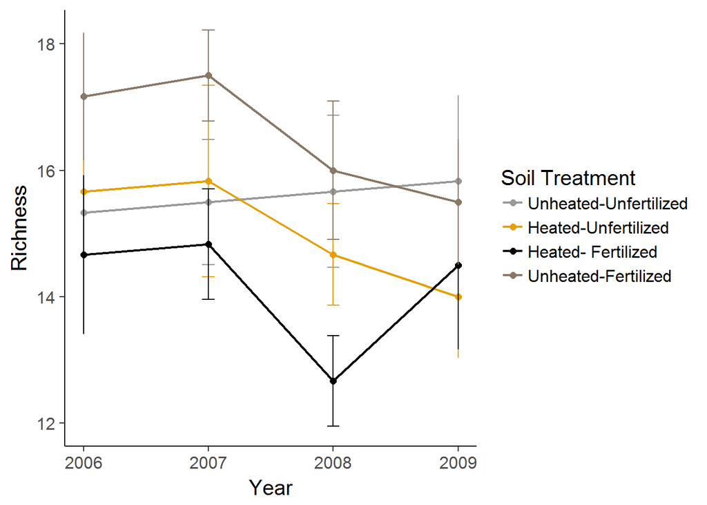

```r
# Calculate observed richness from time-by-species matrix
p_richness = as.data.frame(rowSums(plant[,-c(1:5)] > 0))
# Create data frame with experimental design and richness data
p_rich.all = data.frame(plant[,1:5,], p_richness)
# Rename column
names(p_rich.all)[6] = "richness"

# avg. richness per group
# stand. dev. per group
# num. obs. per group
# calc. std. err. mean.
p_rich.treat.plot = group_by(p_rich.all, treatment, year) %>%
  summarise(mean = mean(richness), sd = sd(richness),n = n(),sem = sd/sqrt(n))

p_rich.plot = ggplot(p_rich.treat.plot, aes(x = year, y = mean, color = as.factor(treatment))) +
               geom_point(size = 2, show.legend = T) +
               geom_line(size = 0.75) +
  geom_errorbar(aes(ymin = mean - sem, ymax = mean + sem), width = .1) +
               scale_color_manual(values = c("#999999", "#E69F00", "#000000", "#8B7765"),name="Soil Treatment",labels=c("Unheated-Unfertilized", "Heated-Unfertilized", "Heated- Fertilized", "Unheated-Fertilized")) +
               xlim(2006, 2009) + xlab("Year") + ylab("Richness") +
               theme_classic(base_size=15)+
               theme(axis.line.x = element_line(color = "black"), axis.line.y = element_line(color ="black"))
plot(p_rich.plot)
```

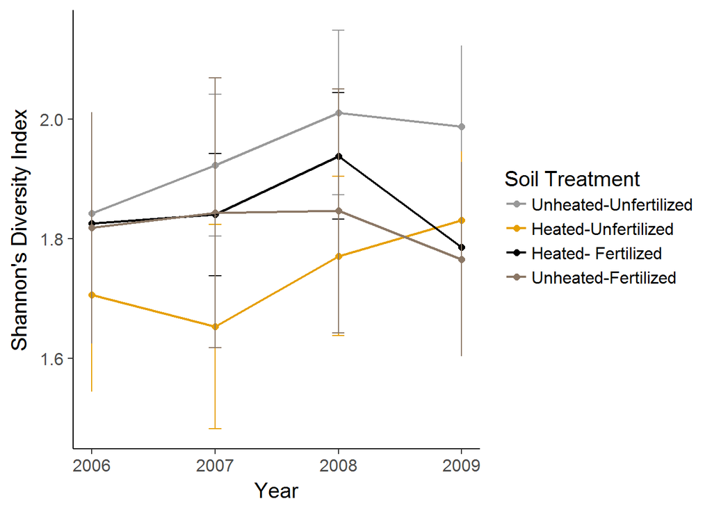

```r
# Calculate diveristy from time-by-species matrix
p_diversity = diversity(plant[,-c(1:5)], "shannon")

# Create data frame with experimental design and diversity data
p_div.all = data.frame(plant[,1:5,], p_diversity)
# Rename column
names(p_div.all)[6] = "diversity"

p_div.treat.plot = group_by(p_div.all, treatment, year) %>%
  summarise(mean = mean(diversity), sd = sd(diversity),n = n(),sem = sd/sqrt(n))

p_div.plot = ggplot(p_div.treat.plot, aes(x = year, y = mean, color = as.factor(treatment))) +
               geom_point(size = 2, show.legend = T) +
               geom_line(size = 0.75) +
               geom_errorbar(aes(ymin = mean - sem, ymax = mean + sem), width = .1) +
               scale_color_manual(values = c("#999999", "#E69F00", "#000000", "#8B7765"),name="Soil Treatment",labels=c("Unheated-Unfertilized", "Heated-Unfertilized", "Heated- Fertilized", "Unheated-Fertilized"))  +
               xlim(2006, 2009) + xlab("Year") + ylab("Shannon's Diversity Index")+
               theme_classic(base_size=15)+
               theme(axis.line.x = element_line(color = "black"),axis.line.y = element_line(color = "black"))
plot(p_div.plot)
```

### BIODIVERSITY HYPOTHESIS TESTING

```r
p_rich.rm = lme(richness ~ year + heat_treat + N_treat * heat_treat * N_treat * year, random = ~ 1 | plot, correlation = corAR1(form = ~ 1 | plot),data = p_rich.all)
summary(p_rich.rm)
```

```
## Linear mixed-effects model fit by REML
##  Data: p_rich.all
##        AIC      BIC    logLik
##   418.1614 445.4121 -198.0807
##
## Random effects:
##  Formula: ~1 | plot
##         (Intercept) Residual
## StdDev:    2.253468 1.497991
##
## Correlation Structure: AR(1)
##  Formula: ~1 | plot
##  Parameter estimate(s):
##         Phi
## -0.09584397
## Fixed effects: richness ~ year + heat_treat + N_treat * heat_treat * N_treat *      year
##                                                Value Std.Error DF
## (Intercept)                                -319.0000  533.6371 68
## year                                          0.1667    0.2658 68
## heat_treatheated                           1589.7925  754.6768 20
## N_treatN fertilized                        1667.9090  754.6768 20
## heat_treatheated:N_treatN fertilized      -2327.7884 1067.2742 20
## year:N_treatN fertilized                     -0.8304    0.3759 68
## year:heat_treatheated                        -0.7922    0.3759 68
## year:heat_treatheated:N_treatN fertilized     1.1586    0.5316 68
##                                              t-value p-value
## (Intercept)                               -0.5977845  0.5520
## year                                       0.6269876  0.5328
## heat_treatheated                           2.1065871  0.0480
## N_treatN fertilized                        2.2100970  0.0389
## heat_treatheated:N_treatN fertilized      -2.1810593  0.0413
## year:N_treatN fertilized                  -2.2088181  0.0306
## year:heat_treatheated                     -2.1072957  0.0388
## year:heat_treatheated:N_treatN fertilized  2.1793094  0.0328
##  Correlation:
##                                           (Intr) year   ht_trt N_trNf
## year                                      -1.000
## heat_treatheated                          -0.707  0.707
## N_treatN fertilized                       -0.707  0.707  0.500
## heat_treatheated:N_treatN fertilized       0.500 -0.500 -0.707 -0.707
## year:N_treatN fertilized                   0.707 -0.707 -0.500 -1.000
## year:heat_treatheated                      0.707 -0.707 -1.000 -0.500
## year:heat_treatheated:N_treatN fertilized -0.500  0.500  0.707  0.707
##                                           h_:N_f y:N_Nf yr:ht_
## year
## heat_treatheated
## N_treatN fertilized
## heat_treatheated:N_treatN fertilized
## year:N_treatN fertilized                   0.707
## year:heat_treatheated                      0.707  0.500
## year:heat_treatheated:N_treatN fertilized -1.000 -0.707 -0.707
##
## Standardized Within-Group Residuals:
##        Min         Q1        Med         Q3        Max
## -2.5089111 -0.5625465  0.1048975  0.6703417  1.6948990
##
## Number of Observations: 96
## Number of Groups: 24
```

```r
anova(p_rich.rm)
```

```
##                         numDF denDF   F-value p-value
## (Intercept)                 1    68 1014.4761  <.0001
## year                        1    68    7.1322  0.0095
## heat_treat                  1    20    2.3242  0.1430
## N_treat                     1    20    0.0011  0.9737
## heat_treat:N_treat          1    20    0.9445  0.3427
## year:N_treat                1    68    0.8920  0.3483
## year:heat_treat             1    68    0.6414  0.4260
## year:heat_treat:N_treat     1    68    4.7494  0.0328
```

```r
# Make cleaner ANOVA table
set.caption("RMANOVA for Plant Richness Data")
pander(anova(p_rich.rm))
```

RMANOVA for Plant Richness Data

|  | numDF | denDF | F-value | p-value |
| --- | --- | --- | --- | --- |
| **(Intercept)** | 1 | 68 | 1014 | 0 |
| **year** | 1 | 68 | 7.132 | 0.009464 |
| **heat_treat** | 1 | 20 | 2.324 | 0.143 |
| **N_treat** | 1 | 20 | 0.001114 | 0.9737 |
| **heat_treat:N_treat** | 1 | 20 | 0.9445 | 0.3427 |
| **year:N_treat** | 1 | 68 | 0.892 | 0.3483 |
| **year:heat_treat** | 1 | 68 | 0.6414 | 0.426 |
| **year:heat_treat:N_treat** | 1 | 68 | 4.749 | 0.03278 |

```r
# Perform an RM-ANOVA and construct a F-test using the AR(1)
p_div.rm = lme(diversity ~year + heat_treat + N_treat * heat_treat * N_treat * year, random = ~ 1 | plot, correlation = corAR1(form = ~ 1 | plot),data = p_div.all) # Look at detailed output
summary(p_div.rm)
```

```
## Linear mixed-effects model fit by REML
##  Data: p_div.all
##        AIC      BIC    logLik
##   45.91417 73.16488 -11.95709
##
## Random effects:
##  Formula: ~1 | plot
##         (Intercept)  Residual
## StdDev:   0.2416783 0.2710299
##
## Correlation Structure: AR(1)
##  Formula: ~1 | plot
##  Parameter estimate(s):
##       Phi
## 0.6311864
## Fixed effects: diversity ~ year + heat_treat + N_treat * heat_treat * N_treat *      year
##                                               Value Std.Error DF
## (Intercept)                               -96.42080  90.53669 68
## year                                        0.04899   0.04510 68
## heat_treatheated                           11.63861 128.03821 20
## N_treatN fertilized                       132.51317 128.03821 20
## heat_treatheated:N_treatN fertilized      -23.36506 181.07338 20
## year:N_treatN fertilized                   -0.06607   0.06378 68
## year:heat_treatheated                      -0.00589   0.06378 68
## year:heat_treatheated:N_treatN fertilized   0.01174   0.09020 68
##                                              t-value p-value
## (Intercept)                               -1.0649915  0.2906
## year                                       1.0863041  0.2812
## heat_treatheated                           0.0908995  0.9285
## N_treatN fertilized                        1.0349501  0.3130
## heat_treatheated:N_treatN fertilized      -0.1290364  0.8986
## year:N_treatN fertilized                  -1.0359107  0.3039
## year:heat_treatheated                     -0.0922735  0.9268
## year:heat_treatheated:N_treatN fertilized  0.1301299  0.8968
##  Correlation:
##                                           (Intr) year   ht_trt N_trNf
## year                                      -1.000
## heat_treatheated                          -0.707  0.707
## N_treatN fertilized                       -0.707  0.707  0.500
## heat_treatheated:N_treatN fertilized       0.500 -0.500 -0.707 -0.707
## year:N_treatN fertilized                   0.707 -0.707 -0.500 -1.000
## year:heat_treatheated                      0.707 -0.707 -1.000 -0.500
## year:heat_treatheated:N_treatN fertilized -0.500  0.500  0.707  0.707
##                                           h_:N_f y:N_Nf yr:ht_
## year
## heat_treatheated
## N_treatN fertilized
## heat_treatheated:N_treatN fertilized
## year:N_treatN fertilized                   0.707
## year:heat_treatheated                      0.707  0.500
## year:heat_treatheated:N_treatN fertilized -1.000 -0.707 -0.707
##
## Standardized Within-Group Residuals:
##        Min         Q1        Med         Q3        Max
## -2.0663335 -0.2975686  0.1382110  0.5149486  1.6528550
##
## Number of Observations: 96
## Number of Groups: 24
```

```r
anova(p_div.rm)
```

```
##                         numDF denDF  F-value p-value
## (Intercept)                 1    68 786.2574  <.0001
## year                        1    68   0.5002  0.4818
## heat_treat                  1    20   0.3474  0.5622
## N_treat                     1    20   0.0334  0.8568
## heat_treat:N_treat          1    20   0.5754  0.4569
## year:N_treat                1    68   1.7819  0.1864
## year:heat_treat             1    68   0.0000  0.9997
## year:heat_treat:N_treat     1    68   0.0169  0.8968
```

```r
set.caption("RMANOVA for Plant Diversity Data")
pander(anova(p_div.rm))
```

|  | numDF | denDF | F-value | p-value |
| --- | --- | --- | --- | --- |
| **(Intercept)** | 1 | 68 | 786.3 | 0 |
| **year** | 1 | 68 | 0.5002 | 0.4818 |
| **heat_treat** | 1 | 20 | 0.3474 | 0.5622 |
| **N_treat** | 1 | 20 | 0.03342 | 0.8568 |
| **heat_treat:N_treat** | 1 | 20 | 0.5754 | 0.4569 |
| **year:N_treat** | 1 | 68 | 1.782 | 0.1864 |
| **year:heat_treat** | 1 | 68 | 1.329e-07 | 0.9997 |
| **year:heat_treat:N_treat** | 1 | 68 | 0.01693 | 0.8968 |

```r
# Making the wide site by species format into a long format- to get abundances for each species
plant$row_id = 1:nrow(plant)
p.id = dplyr::select(plant, row_id, year, treatment)
plant.m = as.matrix(plant_sbys)
m1 = setNames(melt(plant.m), c('row_id','species','count'))
m2 = dplyr::filter(m1, count > 0)
m3 = expandRows(m2, "count")
plant_long = left_join(p.id,m3, by = "row_id")
p_long = dplyr::select(plant_long, -row_id)

# Calculate species abundances for each taxonomic group
plant.sp.abunds = p_long %>%
                     group_by(year,treatment) %>%
                     count(species)
write.csv(plant.sp.abunds, file = "plant abundances")
# Calculate total turnover
plant.total = turnover(df = plant.sp.abunds, time.var = "year",
                            species.var = "species",
                            abundance.var = "n",
                            replicate.var = "treatment",
                            metric = "total")
# Calculate species gained
plant.appearance = turnover(df = plant.sp.abunds, time.var = "year",
                            species.var = "species",
                            abundance.var = "n",
                            replicate.var = "treatment",
                            metric = "appearance")
# Calculate species lost
plant.disappearance = turnover(df = plant.sp.abunds, time.var = "year",
                            species.var = "species",
                            abundance.var = "n",
                            replicate.var = "treatment",
                            metric = "disappearance")

plant.turnover = full_join(plant.total, plant.disappearance) %>%
                  full_join(plant.appearance)
```

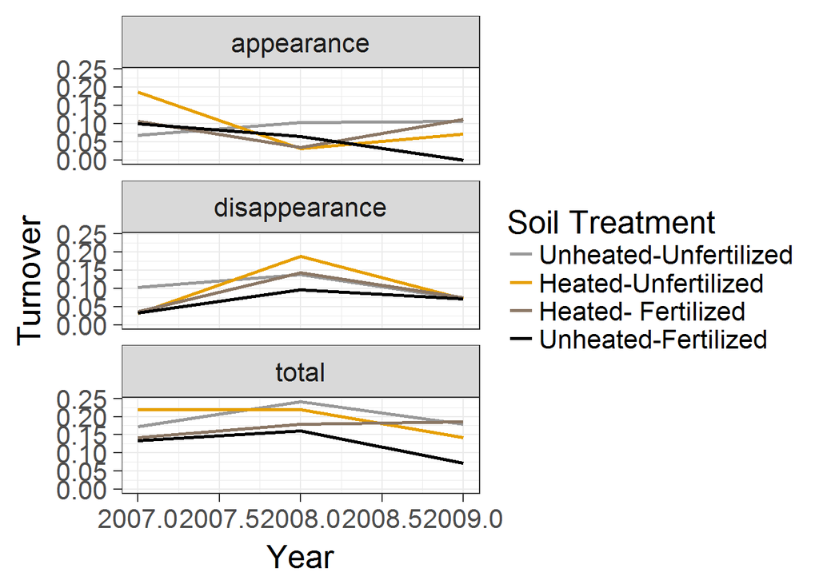

```r
plant.turnover = gather(plant.turnover, key = metric, value = turnover, total, appearance, disappearance)
View(plant.turnover)

# 3. Visualize turnover within each group

plant.turn.plot = ggplot(plant.turnover, aes(x = year, y = turnover, color = treatment)) +
  geom_line(size = 1, show.legend = T) + facet_wrap(~metric, ncol = 1) +
  xlim(2007, 2009) +
  xlab("Year") +
  ylab("Turnover") +
  scale_color_manual(values = c("#999999", "#E69F00","#8B7765", "#000000"),name="Soil Treatment",labels=c("Unheated-Unfertilized", "Heated-Unfertilized", "Heated- Fertilized", "Unheated-Fertilized"))+
  theme_bw(base_size=20)
plot(plant.turn.plot)
```

```
## geom_path: Each group consists of only one observation. Do you need to
## adjust the group aesthetic?
```

[output not shown]

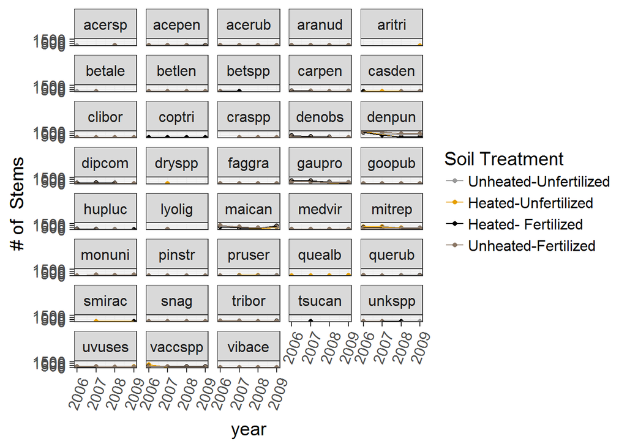

```r
# Low turnover is indicative of a stable community and high turnover is indicative of a dynamic community

# Abundance Plot treatment by year
p_abun.plot1 = ggplot(plant.sp.abunds, aes(year, n, color= as.factor(treatment))) +
              geom_point() +
              geom_line(aes(color = as.factor(treatment))) +
              facet_wrap(~species, nrow = 8) +
              scale_color_manual(values = c("#999999", "#E69F00", "#000000", "#8B7765"),name="Soil Treatment",labels=c("Unheated-Unfertilized", "Heated-Unfertilized", "Heated- Fertilized", "Unheated-Fertilized"))  +
              ylab("# of  Stems") +
              theme_bw(base_size=15) +
              theme(axis.text.x = element_text(angle=70, vjust=0.5))
plot(p_abun.plot1)
```

[figure not shown]

```r
# Abundances across years
p_abun.plot2 = ggplot(plant.sp.abunds , aes(x = species, y = n)) +
                  geom_bar(stat = "identity") +
                  facet_wrap(~year, ncol = 1) +
                  ylab("# of  Stems") +
                  theme_bw(base_size=25) +
                  theme(axis.text.x = element_text(angle=70, vjust=0.5))
plot(p_abun.plot2)
```

### B. Rank Shift

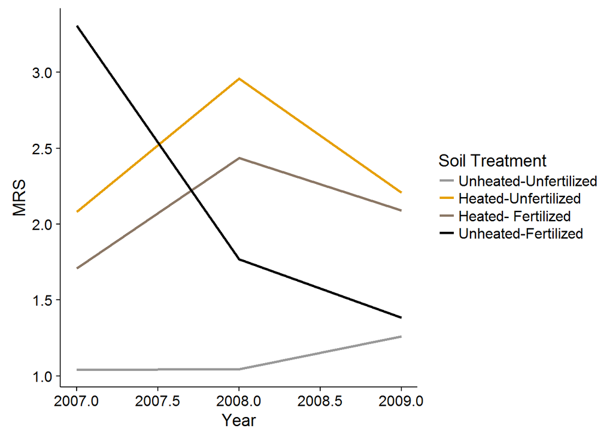

```r
# Calculate species abundances for each treatment group
plant.sp.abunds = p_long %>%
                     group_by(year,treatment) %>%
                     count(species)

# Calculate MRS
plant.rankshift = rank_shift(df = as.data.frame(plant.sp.abunds),
                              time.var = "year",
                              species.var = "species",
                              abundance.var = "n",
                              replicate.var = "treatment")

plant.rankshift$year = as.numeric(substr(plant.rankshift$year_pair, 6, 9))

# Create ggplot
rankshift.plot =  ggplot(plant.rankshift, aes(x = year, y = MRS, color = treatment)) + geom_line(size = 1) +
xlim(2007, 2009) +
xlab("Year") +
scale_color_manual(values = c("#999999", "#E69F00", "#8B7765", "#000000"),name="Soil Treatment",labels=c("Unheated-Unfertilized", "Heated-Unfertilized", "Heated- Fertilized", "Unheated-Fertilized"))
plot(rankshift.plot)
```

```r
plant.rankshift %>%
  group_by (treatment) %>%
  summarise(mean = mean(MRS), cv = sd(MRS)/mean)
```

```
## # A tibble: 4 × 3
##   treatment     mean        cv
##       <chr>    <dbl>     <dbl>
## 1         1 1.115997 0.1124355
## 2         2 2.416111 0.1967510
## 3         3 2.078008 0.1748773
## 4         4 2.153846 0.4724556
```

[figure not shown]

```r
# Rank Clock
ag_plant.dat = aggregate(n ~ species * year * treatment,
                    data = subset(plant.sp.abunds,
                                    species == "denpun" |
                                    species == "maican" |
                                    species == "mitrep"|
                                    species == "gaupro"), FUN = mean)
write.csv(ag_plant.dat, file = "dominant plant abundances.csv")
rclock_plot = ggplot(ag_plant.dat, aes(year, n, color = species)) +
        geom_line(size = 1) + coord_polar() + theme_bw(base_size = 25) +
        facet_wrap(~treatment) +
        ylab("# of Stems") +
        scale_color_manual(values = c("#2F4F4F", "#FF4040", "#8FBC8F", "#C0C0C0")) +
        ggtitle("Dominant species abundances \n for the different soil treatments, Harvard Forest \n")
plot(rclock_plot)
```

```r
# Species Codes: Denpun = Dennstaedtia punctilobula, Gauopro = Gaultheria procumbens, maican = Maianthemum canadense, vaccpp = number of stems of Vaccinium species (corymbosum, angustifolium, vacillans)
```

### A. Plots

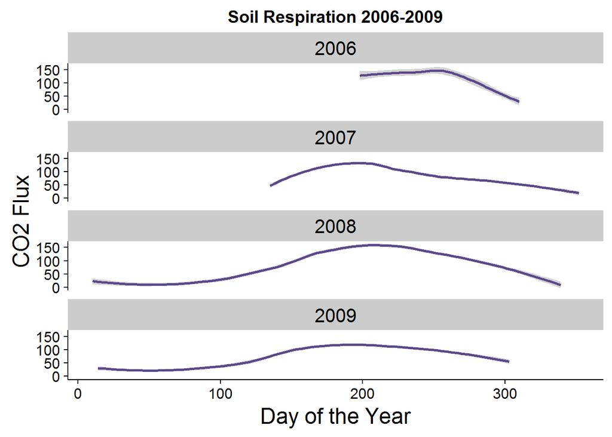

```r
# Soil respiration
resp = resp %>%
    filter(year %in% c( "2006","2007", "2008", "2009"))
resp$date = as.Date(resp$date, format = "%m/%d/%Y")
resp$doy = yday(resp$date)
resp = na.exclude(resp)

resp_yr.plot = qplot(doy, co2flux, data = resp, geom="smooth") +
         stat_smooth(fill="azure3", colour="mediumpurple4", size=1, alpha = 0.2) +
         theme(panel.grid.major = element_blank(), panel.grid.minor = element_blank(),
            panel.background = element_blank(), axis.line =   element_line(colour = "black")) +
        facet_wrap(~year, ncol = 1) +
        xlab("Day of the Year") +
        ylab("CO2 Flux")
resp_yr.plot + theme(text = element_text(size=18), plot.title = element_text(lineheight=.8, face="bold")) + ggtitle("Soil Respiration 2006-2009")
```

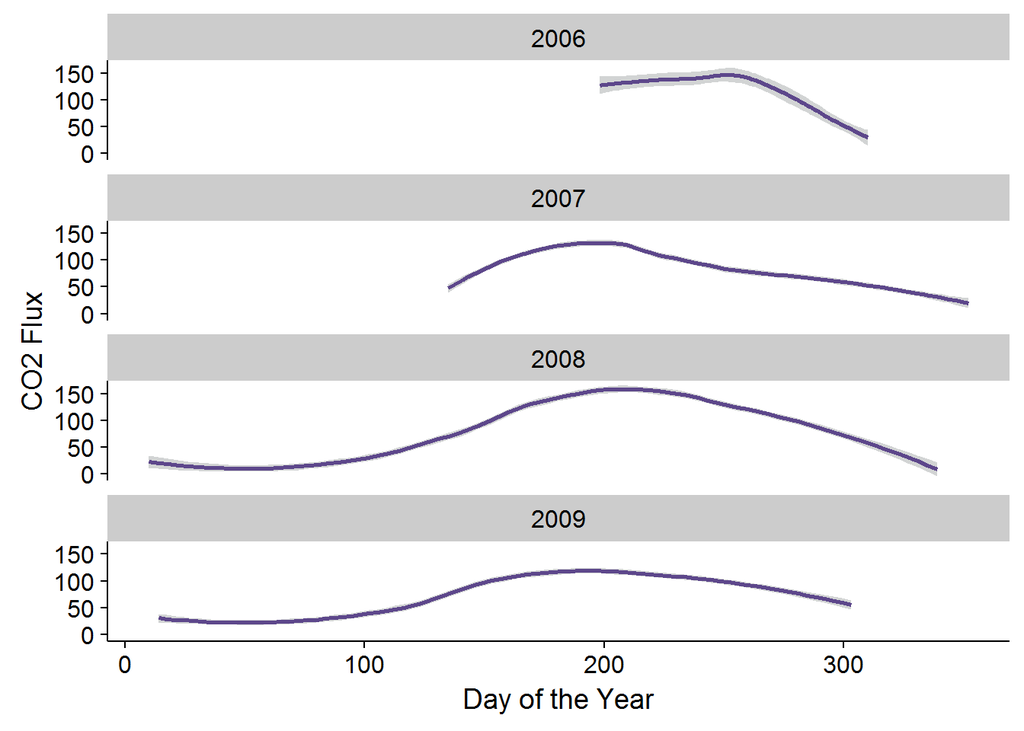

```r
plot(resp_yr.plot)
```

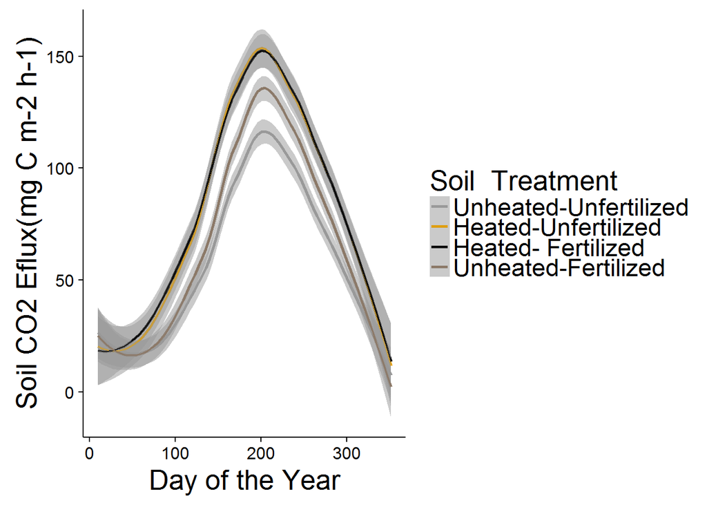

```r
resp_trt.plot = qplot(doy, co2flux, data = resp, colour = as.factor(trt), geom="smooth") +
      stat_smooth(method ="auto",se = TRUE, formula = y ~ x, size = 0.5, alpha =0.2) +
      theme(panel.grid.major = element_blank(), panel.grid.minor = element_blank(),
            panel.background = element_blank(), axis.line = element_line(colour = "black")) +
            scale_color_manual(values = c("#999999", "#E69F00", "#000000", "#8B7765"),name="Soil  Treatment",labels=c("Unheated-Unfertilized", "Heated-Unfertilized", "Heated- Fertilized", "Unheated-Fertilized"))  +
              xlab("Day of the Year") +
              ylab("Soil CO2 Eflux(mg C m-2 h-1)") +
              theme(text = element_text(size=20))
plot(resp_trt.plot)
```

### B. Hypothesis Testing

```r
# Soil Respiration
resp.treat.mean = group_by(resp, trt) %>%
  summarise(mean = mean(co2flux), sd = sd(co2flux),n = n(),sem = sd/sqrt(n))

# Trying different variance - covariance structures
# AR(1) covariance structure
soil.rm1 = lme(co2flux ~ year + heat_treat + N_treat * heat_treat * N_treat * year , random = ~ 1 | plot, correlation = corAR1(form = ~ 1 | plot),data = resp)
summary(soil.rm1) # Obtain F-test
```

```
## Linear mixed-effects model fit by REML
##  Data: resp
##       AIC      BIC  logLik
##   12193.8 12249.96 -6085.9
##
## Random effects:
##  Formula: ~1 | plot
##         (Intercept) Residual
## StdDev:  0.04868632 54.29218
##
## Correlation Structure: AR(1)
##  Formula: ~1 | plot
##  Parameter estimate(s):
##       Phi
## 0.7650751
## Fixed effects: co2flux ~ year + heat_treat + N_treat * heat_treat * N_treat *      year
##                                               Value Std.Error   DF
## (Intercept)                                9685.752 12014.206 1197
## year                                         -4.791     5.984 1197
## heat_treatheated                           5707.207 16882.156 1197
## N_treatN fertilized                       -5761.977 16796.061 1197
## heat_treatheated:N_treatN fertilized       3653.012 23965.367   22
## year:N_treatN fertilized                      2.875     8.366 1197
## year:heat_treatheated                        -2.833     8.409 1197
## year:heat_treatheated:N_treatN fertilized    -1.822    11.937 1197
##                                              t-value p-value
## (Intercept)                                0.8061917  0.4203
## year                                      -0.8005555  0.4235
## heat_treatheated                           0.3380615  0.7354
## N_treatN fertilized                       -0.3430553  0.7316
## heat_treatheated:N_treatN fertilized       0.1524288  0.8802
## year:N_treatN fertilized                   0.3436185  0.7312
## year:heat_treatheated                     -0.3369009  0.7363
## year:heat_treatheated:N_treatN fertilized -0.1526663  0.8787
##  Correlation:
##                                           (Intr) year   ht_trt N_trNf
## year                                      -1.000
## heat_treatheated                          -0.712  0.712
## N_treatN fertilized                       -0.715  0.715  0.526
## heat_treatheated:N_treatN fertilized       0.501 -0.501 -0.716 -0.713
## year:N_treatN fertilized                   0.715 -0.715 -0.526 -1.000
## year:heat_treatheated                      0.712 -0.712 -1.000 -0.526
## year:heat_treatheated:N_treatN fertilized -0.501  0.501  0.716  0.713
##                                           h_:N_f y:N_Nf yr:ht_
## year
## heat_treatheated
## N_treatN fertilized
## heat_treatheated:N_treatN fertilized
## year:N_treatN fertilized                   0.713
## year:heat_treatheated                      0.716  0.526
## year:heat_treatheated:N_treatN fertilized -1.000 -0.713 -0.716
##
## Standardized Within-Group Residuals:
##        Min         Q1        Med         Q3        Max
## -1.4855614 -0.8707739 -0.2082458  0.6043130  5.7170426
##
## Number of Observations: 1227
## Number of Groups: 24
```

```r
anova(soil.rm1)
```

```
##                         numDF denDF  F-value p-value
## (Intercept)                 1  1197 407.3546  <.0001
## year                        1  1197   3.0510  0.0809
## heat_treat                  1  1197   4.2642  0.0391
## N_treat                     1  1197   0.7549  0.3851
## heat_treat:N_treat          1    22   0.1341  0.7177
## year:N_treat                1  1197   0.1261  0.7226
## year:heat_treat             1  1197   0.4087  0.5227
## year:heat_treat:N_treat     1  1197   0.0233  0.8787
```

```r
# corARMA autoregressive moving average proccess
soil.rm2 = lme(co2flux ~ year + heat_treat + N_treat * heat_treat * N_treat * year , random = ~ 1 | plot, correlation = corCompSymm(form = ~ 1 | plot),data = resp) #
summary(soil.rm2) # Obtain F-test
```

```
## Linear mixed-effects model fit by REML
##  Data: resp
##        AIC      BIC    logLik
##   13224.39 13280.56 -6601.197
##
## Random effects:
##  Formula: ~1 | plot
##         (Intercept) Residual
## StdDev:    12.33154  52.8103
##
## Correlation Structure: Compound symmetry
##  Formula: ~1 | plot
##  Parameter estimate(s):
## Rho
##   0
## Fixed effects: co2flux ~ year + heat_treat + N_treat * heat_treat * N_treat *      year
##                                               Value Std.Error   DF
## (Intercept)                               19008.191  6343.268 1197
## year                                         -9.436     3.159 1197
## heat_treatheated                           6260.049  8976.043 1197
## N_treatN fertilized                       -5509.047  8960.614 1197
## heat_treatheated:N_treatN fertilized       5272.973 12624.286   22
## year:N_treatN fertilized                      2.750     4.463 1197
## year:heat_treatheated                        -3.107     4.471 1197
## year:heat_treatheated:N_treatN fertilized    -2.631     6.288 1197
##                                              t-value p-value
## (Intercept)                                2.9965929  0.0028
## year                                      -2.9865468  0.0029
## heat_treatheated                           0.6974174  0.4857
## N_treatN fertilized                       -0.6148069  0.5388
## heat_treatheated:N_treatN fertilized       0.4176849  0.6802
## year:N_treatN fertilized                   0.6161744  0.5379
## year:heat_treatheated                     -0.6949731  0.4872
## year:heat_treatheated:N_treatN fertilized -0.4184200  0.6757
##  Correlation:
##                                           (Intr) year   ht_trt N_trNf
## year                                      -1.000
## heat_treatheated                          -0.707  0.707
## N_treatN fertilized                       -0.708  0.708  0.499
## heat_treatheated:N_treatN fertilized       0.502 -0.502 -0.710 -0.709
## year:N_treatN fertilized                   0.708 -0.708 -0.499 -1.000
## year:heat_treatheated                      0.707 -0.707 -1.000 -0.499
## year:heat_treatheated:N_treatN fertilized -0.502  0.502  0.710  0.709
##                                           h_:N_f y:N_Nf yr:ht_
## year
## heat_treatheated
## N_treatN fertilized
## heat_treatheated:N_treatN fertilized
## year:N_treatN fertilized                   0.709
## year:heat_treatheated                      0.710  0.499
## year:heat_treatheated:N_treatN fertilized -1.000 -0.709 -0.710
##
## Standardized Within-Group Residuals:
##        Min         Q1        Med         Q3        Max
## -1.8753475 -0.8002387 -0.1344678  0.6750015  5.8030273
##
## Number of Observations: 1227
## Number of Groups: 24
```

```r
anova(soil.rm2)
```

```
##                         numDF denDF  F-value p-value
## (Intercept)                 1  1197 711.9576  <.0001
## year                        1  1197  43.1190  <.0001
## heat_treat                  1  1197   8.4465  0.0037
## N_treat                     1  1197   1.8246  0.1770
## heat_treat:N_treat          1    22   0.6421  0.4315
## year:N_treat                1  1197   0.1942  0.6595
## year:heat_treat             1  1197   1.9862  0.1590
## year:heat_treat:N_treat     1  1197   0.1751  0.6757
```

```r
# cirCAR1 cnt AR process
soil.rm3 = lme(co2flux ~ year + heat_treat + N_treat * heat_treat * N_treat * year , random = ~ 1 | plot, correlation = corCAR1(form = ~ 1 | plot),data = resp)
summary(soil.rm3) # Obtain F-test
```

```
## Linear mixed-effects model fit by REML
##  Data: resp
##       AIC      BIC  logLik
##   12193.8 12249.96 -6085.9
##
## Random effects:
##  Formula: ~1 | plot
##         (Intercept) Residual
## StdDev:   0.0061929 54.29221
##
## Correlation Structure: Continuous AR(1)
##  Formula: ~1 | plot
##  Parameter estimate(s):
##       Phi
## 0.7650753
## Fixed effects: co2flux ~ year + heat_treat + N_treat * heat_treat * N_treat *      year
##                                               Value Std.Error   DF
## (Intercept)                                9685.736 12014.212 1197
## year                                         -4.791     5.984 1197
## heat_treatheated                           5707.204 16882.164 1197
## N_treatN fertilized                       -5761.970 16796.069 1197
## heat_treatheated:N_treatN fertilized       3653.006 23965.379   22
## year:N_treatN fertilized                      2.875     8.366 1197
## year:heat_treatheated                        -2.833     8.409 1197
## year:heat_treatheated:N_treatN fertilized    -1.822    11.937 1197
##                                              t-value p-value
## (Intercept)                                0.8061899  0.4203
## year                                      -0.8005537  0.4235
## heat_treatheated                           0.3380612  0.7354
## N_treatN fertilized                       -0.3430547  0.7316
## heat_treatheated:N_treatN fertilized       0.1524285  0.8802
## year:N_treatN fertilized                   0.3436180  0.7312
## year:heat_treatheated                     -0.3369006  0.7363
## year:heat_treatheated:N_treatN fertilized -0.1526659  0.8787
##  Correlation:
##                                           (Intr) year   ht_trt N_trNf
## year                                      -1.000
## heat_treatheated                          -0.712  0.712
## N_treatN fertilized                       -0.715  0.715  0.526
## heat_treatheated:N_treatN fertilized       0.501 -0.501 -0.716 -0.713
## year:N_treatN fertilized                   0.715 -0.715 -0.526 -1.000
## year:heat_treatheated                      0.712 -0.712 -1.000 -0.526
## year:heat_treatheated:N_treatN fertilized -0.501  0.501  0.716  0.713
##                                           h_:N_f y:N_Nf yr:ht_
## year
## heat_treatheated
## N_treatN fertilized
## heat_treatheated:N_treatN fertilized
## year:N_treatN fertilized                   0.713
## year:heat_treatheated                      0.716  0.526
## year:heat_treatheated:N_treatN fertilized -1.000 -0.713 -0.716
##
## Standardized Within-Group Residuals:
##        Min         Q1        Med         Q3        Max
## -1.4855628 -0.8707742 -0.2082468  0.6043113  5.7170404
##
## Number of Observations: 1227
## Number of Groups: 24
```

```r
anova(soil.rm3)
```

```
##                         numDF denDF  F-value p-value
## (Intercept)                 1  1197 407.3562  <.0001
## year                        1  1197   3.0510  0.0809
## heat_treat                  1  1197   4.2643  0.0391
## N_treat                     1  1197   0.7549  0.3851
## heat_treat:N_treat          1    22   0.1341  0.7177
## year:N_treat                1  1197   0.1261  0.7226
## year:heat_treat             1  1197   0.4087  0.5227
## year:heat_treat:N_treat     1  1197   0.0233  0.8787
```

```r
# corARMA autoregressive moving average process, with arbitrary components
soil.rm4 = lme(co2flux ~ year + heat_treat + N_treat * heat_treat * N_treat * year , random = ~ 1 | plot, correlation = corARMA(form = ~ 1 | plot, p = 1, q = 1),data = resp)
summary(soil.rm4) # Obtain F-test
```

```
## Linear mixed-effects model fit by REML
##  Data: resp
##        AIC      BIC   logLik
##   12184.46 12245.73 -6080.23
##
## Random effects:
##  Formula: ~1 | plot
##         (Intercept) Residual
## StdDev: 0.009913942 54.36617
##
## Correlation Structure: ARMA(1,1)
##  Formula: ~1 | plot
##  Parameter estimate(s):
##      Phi1    Theta1
## 0.7206300 0.1122147
## Fixed effects: co2flux ~ year + heat_treat + N_treat * heat_treat * N_treat *      year
##                                               Value Std.Error   DF
## (Intercept)                                9310.932 11713.010 1197
## year                                         -4.604     5.834 1197
## heat_treatheated                           3942.018 16465.233 1197
## N_treatN fertilized                       -6992.177 16384.659 1197
## heat_treatheated:N_treatN fertilized       5245.718 23358.892   22
## year:N_treatN fertilized                      3.487     8.161 1197
## year:heat_treatheated                        -1.953     8.201 1197
## year:heat_treatheated:N_treatN fertilized    -2.616    11.635 1197
##                                              t-value p-value
## (Intercept)                                0.7949222  0.4268
## year                                      -0.7891874  0.4302
## heat_treatheated                           0.2394147  0.8108
## N_treatN fertilized                       -0.4267515  0.6696
## heat_treatheated:N_treatN fertilized       0.2245705  0.8244
## year:N_treatN fertilized                   0.4273296  0.6692
## year:heat_treatheated                     -0.2381811  0.8118
## year:heat_treatheated:N_treatN fertilized -0.2248353  0.8221
##  Correlation:
##                                           (Intr) year   ht_trt N_trNf
## year                                      -1.000
## heat_treatheated                          -0.711  0.711
## N_treatN fertilized                       -0.715  0.715  0.524
## heat_treatheated:N_treatN fertilized       0.501 -0.501 -0.716 -0.712
## year:N_treatN fertilized                   0.715 -0.715 -0.524 -1.000
## year:heat_treatheated                      0.711 -0.711 -1.000 -0.524
## year:heat_treatheated:N_treatN fertilized -0.501  0.501  0.716  0.712
##                                           h_:N_f y:N_Nf yr:ht_
## year
## heat_treatheated
## N_treatN fertilized
## heat_treatheated:N_treatN fertilized
## year:N_treatN fertilized                   0.712
## year:heat_treatheated                      0.716  0.524
## year:heat_treatheated:N_treatN fertilized -1.000 -0.712 -0.716
##
## Standardized Within-Group Residuals:
##        Min         Q1        Med         Q3        Max
## -1.4830352 -0.8680755 -0.2048938  0.6109948  5.6997263
##
## Number of Observations: 1227
## Number of Groups: 24
```

```r
anova(soil.rm4)
```

```
##                         numDF denDF  F-value p-value
## (Intercept)                 1  1197 457.5664  <.0001
## year                        1  1197   2.3703  0.1239
## heat_treat                  1  1197   5.1306  0.0237
## N_treat                     1  1197   0.7796  0.3774
## heat_treat:N_treat          1    22   0.1771  0.6779
## year:N_treat                1  1197   0.1579  0.6911
## year:heat_treat             1  1197   0.3266  0.5678
## year:heat_treat:N_treat     1  1197   0.0506  0.8221
```

```r
#corExp exponential spatial correlation.
soil.rm5 = lme(co2flux ~ year + heat_treat + N_treat * heat_treat * N_treat * year , random = ~ 1 | plot, correlation = corExp(form = ~ 1 | plot),data = resp)
summary(soil.rm5) # Obtain F-test
```

```
## Linear mixed-effects model fit by REML
##  Data: resp
##       AIC      BIC  logLik
##   12193.8 12249.96 -6085.9
##
## Random effects:
##  Formula: ~1 | plot
##         (Intercept) Residual
## StdDev:  0.00874299 54.29221
##
## Correlation Structure: Exponential spatial correlation
##  Formula: ~1 | plot
##  Parameter estimate(s):
##    range
## 3.734394
## Fixed effects: co2flux ~ year + heat_treat + N_treat * heat_treat * N_treat *      year
##                                               Value Std.Error   DF
## (Intercept)                                9685.738 12014.211 1197
## year                                         -4.791     5.984 1197
## heat_treatheated                           5707.204 16882.163 1197
## N_treatN fertilized                       -5761.970 16796.068 1197
## heat_treatheated:N_treatN fertilized       3653.007 23965.378   22
## year:N_treatN fertilized                      2.875     8.366 1197
## year:heat_treatheated                        -2.833     8.409 1197
## year:heat_treatheated:N_treatN fertilized    -1.822    11.937 1197
##                                              t-value p-value
## (Intercept)                                0.8061901  0.4203
## year                                      -0.8005539  0.4235
## heat_treatheated                           0.3380612  0.7354
## N_treatN fertilized                       -0.3430547  0.7316
## heat_treatheated:N_treatN fertilized       0.1524285  0.8802
## year:N_treatN fertilized                   0.3436180  0.7312
## year:heat_treatheated                     -0.3369006  0.7363
## year:heat_treatheated:N_treatN fertilized -0.1526660  0.8787
##  Correlation:
##                                           (Intr) year   ht_trt N_trNf
## year                                      -1.000
## heat_treatheated                          -0.712  0.712
## N_treatN fertilized                       -0.715  0.715  0.526
## heat_treatheated:N_treatN fertilized       0.501 -0.501 -0.716 -0.713
## year:N_treatN fertilized                   0.715 -0.715 -0.526 -1.000
## year:heat_treatheated                      0.712 -0.712 -1.000 -0.526
## year:heat_treatheated:N_treatN fertilized -0.501  0.501  0.716  0.713
##                                           h_:N_f y:N_Nf yr:ht_
## year
## heat_treatheated
## N_treatN fertilized
## heat_treatheated:N_treatN fertilized
## year:N_treatN fertilized                   0.713
## year:heat_treatheated                      0.716  0.526
## year:heat_treatheated:N_treatN fertilized -1.000 -0.713 -0.716
##
## Standardized Within-Group Residuals:
##        Min         Q1        Med         Q3        Max
## -1.4855629 -0.8707742 -0.2082468  0.6043114  5.7170408
##
## Number of Observations: 1227
## Number of Groups: 24
```

```r
anova(soil.rm5)
```

```
##                         numDF denDF  F-value p-value
## (Intercept)                 1  1197 407.3563  <.0001
## year                        1  1197   3.0510  0.0809
## heat_treat                  1  1197   4.2643  0.0391
## N_treat                     1  1197   0.7549  0.3851
## heat_treat:N_treat          1    22   0.1341  0.7177
## year:N_treat                1  1197   0.1261  0.7226
## year:heat_treat             1  1197   0.4087  0.5227
## year:heat_treat:N_treat     1  1197   0.0233  0.8787
```

```r
# CorGaus Gaussian spatial correlation.
soil.rm6 = lme(co2flux ~ year + heat_treat + N_treat * heat_treat * N_treat * year , random = ~ 1 | plot, correlation = corGaus(form = ~ 1 | plot),data = resp)
summary(soil.rm6) # Obtain F-test
```

```
## Linear mixed-effects model fit by REML
##  Data: resp
##        AIC      BIC    logLik
##   12437.69 12493.86 -6207.846
##
## Random effects:
##  Formula: ~1 | plot
##         (Intercept) Residual
## StdDev:    10.69376 48.74015
##
## Correlation Structure: Gaussian spatial correlation
##  Formula: ~1 | plot
##  Parameter estimate(s):
##   range
## 1.28212
## Fixed effects: co2flux ~ year + heat_treat + N_treat * heat_treat * N_treat *      year
##                                               Value Std.Error   DF
## (Intercept)                               15691.395  8146.750 1197
## year                                         -7.783     4.058 1197
## heat_treatheated                           3854.306 11506.838 1197
## N_treatN fertilized                       -8425.135 11470.732 1197
## heat_treatheated:N_treatN fertilized       7756.017 16218.984   22
## year:N_treatN fertilized                      4.202     5.713 1197
## year:heat_treatheated                        -1.909     5.731 1197
## year:heat_treatheated:N_treatN fertilized    -3.867     8.078 1197
##                                              t-value p-value
## (Intercept)                                1.9260926  0.0543
## year                                      -1.9181601  0.0553
## heat_treatheated                           0.3349579  0.7377
## N_treatN fertilized                       -0.7344898  0.4628
## heat_treatheated:N_treatN fertilized       0.4782061  0.6372
## year:N_treatN fertilized                   0.7354333  0.4622
## year:heat_treatheated                     -0.3330064  0.7392
## year:heat_treatheated:N_treatN fertilized -0.4787347  0.6322
##  Correlation:
##                                           (Intr) year   ht_trt N_trNf
## year                                      -1.000
## heat_treatheated                          -0.708  0.708
## N_treatN fertilized                       -0.710  0.710  0.506
## heat_treatheated:N_treatN fertilized       0.502 -0.502 -0.712 -0.710
## year:N_treatN fertilized                   0.710 -0.710 -0.506 -1.000
## year:heat_treatheated                      0.708 -0.708 -1.000 -0.506
## year:heat_treatheated:N_treatN fertilized -0.502  0.502  0.712  0.710
##                                           h_:N_f y:N_Nf yr:ht_
## year
## heat_treatheated
## N_treatN fertilized
## heat_treatheated:N_treatN fertilized
## year:N_treatN fertilized                   0.710
## year:heat_treatheated                      0.712  0.506
## year:heat_treatheated:N_treatN fertilized -1.000 -0.710 -0.712
##
## Standardized Within-Group Residuals:
##        Min         Q1        Med         Q3        Max
## -1.8645120 -0.8903077 -0.1563755  0.7280396  6.2992236
##
## Number of Observations: 1227
## Number of Groups: 24
```

```r
anova(soil.rm6)
```

```
##                         numDF denDF  F-value p-value
## (Intercept)                 1  1197 687.2837  <.0001
## year                        1  1197  14.2721  0.0002
## heat_treat                  1  1197   8.9255  0.0029
## N_treat                     1  1197   1.2587  0.2621
## heat_treat:N_treat          1    22   0.5210  0.4780
## year:N_treat                1  1197   0.3178  0.5731
## year:heat_treat             1  1197   0.9208  0.3375
## year:heat_treat:N_treat     1  1197   0.2292  0.6322
```

```r
# corLin    linear spatial correlation.
soil.rm7 = lme(co2flux ~ year + heat_treat + N_treat * heat_treat * N_treat * year , random = ~ 1 | plot, correlation = corLin(form = ~ 1 | plot),data = resp) #
summary(soil.rm7) # Obtain F-test
```

```
## Linear mixed-effects model fit by REML
##  Data: resp
##        AIC      BIC    logLik
##   12326.72 12382.88 -6152.358
##
## Random effects:
##  Formula: ~1 | plot
##         (Intercept) Residual
## StdDev:  0.03468838  170.535
##
## Correlation Structure: Linear spatial correlation
##  Formula: ~1 | plot
##  Parameter estimate(s):
##    range
## 42.34558
## Fixed effects: co2flux ~ year + heat_treat + N_treat * heat_treat * N_treat *      year
##                                                Value Std.Error   DF
## (Intercept)                                -7989.840  17084.36 1197
## year                                           4.020      8.51 1197
## heat_treatheated                           11977.917  24017.96 1197
## N_treatN fertilized                         1319.883  24063.30 1197
## heat_treatheated:N_treatN fertilized      -13180.793  34176.83   22
## year:N_treatN fertilized                      -0.658     11.98 1197
## year:heat_treatheated                         -5.961     11.96 1197
## year:heat_treatheated:N_treatN fertilized      6.571     17.02 1197
##                                              t-value p-value
## (Intercept)                               -0.4676699  0.6401
## year                                       0.4724529  0.6367
## heat_treatheated                           0.4987067  0.6181
## N_treatN fertilized                        0.0548505  0.9563
## heat_treatheated:N_treatN fertilized      -0.3856646  0.7034
## year:N_treatN fertilized                  -0.0548892  0.9562
## year:heat_treatheated                     -0.4983656  0.6183
## year:heat_treatheated:N_treatN fertilized  0.3859872  0.6996
##  Correlation:
##                                           (Intr) year   ht_trt N_trNf
## year                                      -1.000
## heat_treatheated                          -0.711  0.711
## N_treatN fertilized                       -0.710  0.710  0.516
## heat_treatheated:N_treatN fertilized       0.500 -0.500 -0.711 -0.712
## year:N_treatN fertilized                   0.710 -0.710 -0.516 -1.000
## year:heat_treatheated                      0.711 -0.711 -1.000 -0.516
## year:heat_treatheated:N_treatN fertilized -0.500  0.500  0.711  0.712
##                                           h_:N_f y:N_Nf yr:ht_
## year
## heat_treatheated
## N_treatN fertilized
## heat_treatheated:N_treatN fertilized
## year:N_treatN fertilized                   0.712
## year:heat_treatheated                      0.711  0.516
## year:heat_treatheated:N_treatN fertilized -1.000 -0.712 -0.711
##
## Standardized Within-Group Residuals:
##        Min         Q1        Med         Q3        Max
## -0.5555369 -0.3332354 -0.1174624  0.1434040  1.7858305
##
## Number of Observations: 1227
## Number of Groups: 24
```

```r
anova(soil.rm7)
```

```
##                         numDF denDF   F-value p-value
## (Intercept)                 1  1197 13.884319  0.0002
## year                        1  1197  0.305597  0.5805
## heat_treat                  1  1197  0.071048  0.7899
## N_treat                     1  1197  0.041809  0.8380
## heat_treat:N_treat          1    22  0.013099  0.9099
## year:N_treat                1  1197  0.102430  0.7490
## year:heat_treat             1  1197  0.101428  0.7502
## year:heat_treat:N_treat     1  1197  0.148986  0.6996
```

```r
# corRatio  Rational quadratics spatial correlation.
soil.rm8 = lme(co2flux ~ year + heat_treat + N_treat * heat_treat * N_treat * year , random = ~ 1 | plot, correlation = corRatio(form = ~ 1 | plot),data = resp) #
summary(soil.rm8) # Obtain F-test
```

```
## Linear mixed-effects model fit by REML
##  Data: resp
##        AIC      BIC    logLik
##   12258.98 12315.14 -6118.489
##
## Random effects:
##  Formula: ~1 | plot
##         (Intercept) Residual
## StdDev:    4.022598 50.52358
##
## Correlation Structure: Rational quadratic spatial correlation
##  Formula: ~1 | plot
##  Parameter estimate(s):
##    range
## 1.465046
## Fixed effects: co2flux ~ year + heat_treat + N_treat * heat_treat * N_treat *      year
##                                               Value Std.Error   DF
## (Intercept)                               13057.695 10084.786 1197
## year                                         -6.471     5.023 1197
## heat_treatheated                           3055.431 14211.590 1197
## N_treatN fertilized                       -8211.315 14141.609 1197
## heat_treatheated:N_treatN fertilized       7307.039 20096.611   22
## year:N_treatN fertilized                      4.095     7.044 1197
## year:heat_treatheated                        -1.511     7.079 1197
## year:heat_treatheated:N_treatN fertilized    -3.643    10.010 1197
##                                              t-value p-value
## (Intercept)                                1.2947915  0.1956
## year                                      -1.2882423  0.1979
## heat_treatheated                           0.2149957  0.8298
## N_treatN fertilized                       -0.5806493  0.5616
## heat_treatheated:N_treatN fertilized       0.3635956  0.7196
## year:N_treatN fertilized                   0.5813504  0.5611
## year:heat_treatheated                     -0.2134664  0.8310
## year:heat_treatheated:N_treatN fertilized -0.3639631  0.7159
##  Correlation:
##                                           (Intr) year   ht_trt N_trNf
## year                                      -1.000
## heat_treatheated                          -0.710  0.710
## N_treatN fertilized                       -0.713  0.713  0.516
## heat_treatheated:N_treatN fertilized       0.502 -0.502 -0.714 -0.711
## year:N_treatN fertilized                   0.713 -0.713 -0.516 -1.000
## year:heat_treatheated                      0.710 -0.710 -1.000 -0.516
## year:heat_treatheated:N_treatN fertilized -0.502  0.502  0.714  0.711
##                                           h_:N_f y:N_Nf yr:ht_
## year
## heat_treatheated
## N_treatN fertilized
## heat_treatheated:N_treatN fertilized
## year:N_treatN fertilized                   0.711
## year:heat_treatheated                      0.714  0.516
## year:heat_treatheated:N_treatN fertilized -1.000 -0.711 -0.714
##
## Standardized Within-Group Residuals:
##        Min         Q1        Med         Q3        Max
## -1.5780993 -0.9142183 -0.2011923  0.6785817  6.1249494
##
## Number of Observations: 1227
## Number of Groups: 24
```

```r
anova(soil.rm8)
```

```
##                         numDF denDF  F-value p-value
## (Intercept)                 1  1197 689.1108  <.0001
## year                        1  1197   5.9050  0.0152
## heat_treat                  1  1197   8.6477  0.0033
## N_treat                     1  1197   1.0978  0.2950
## heat_treat:N_treat          1    22   0.3813  0.5432
## year:N_treat                1  1197   0.2213  0.6382
## year:heat_treat             1  1197   0.4577  0.4988
## year:heat_treat:N_treat     1  1197   0.1325  0.7159
```